# CustomerSpendRegressor

Harinarayan Parameswara Sarma

```r
# load the required libraries
library("readxl") # used to read excel files
library("dplyr") # used for data munging
library("FNN") # used for knn regression (knn.reg function)
library("caret") # used for various predictive models
library("class") # for using confusion matrix function
library("rpart.plot") # used to plot decision tree
library("rpart")  # used for Regression tree
library("glmnet") # used for Lasso and Ridge regression
library('NeuralNetTools') # used to plot Neural Networks
library("PRROC") # top plot ROC curve
library("ROCR") # top plot lift curve
library("tidyverse")
library("skimr")
```

# 1. Regression

## 1.1 Data loading and transformation

Please make sure that you have Spending_data.xlsx in your working directory.

This dataset contains data about whether or not different consumers made a purchase in response to a test mailing of a certain catalog and, in case of a purchase, how much money each consumer spent.

The data file has a brief description of all the attributes in 2nd worksheet (Codes). Note that this dataset has two possible outcome variables: Purchase (0/1 value: whether or not the purchase was made) and Spending (numeric value: amount spent). We will focus on predicting how much a person spends, not the binary of whether they will purchase or not.

```r
# read Spending_data.xlsx into a data frame called spending
spending_data <- read_excel("Spending_data.xlsx", sheet = "All Data")
skim(spending_data)
```

Data summary

| Name | spending_data |
| --- | --- |
| Number of rows | 2000 |
| Number of columns | 25 |
| _______________________ |  |
| Column type frequency: |  |
| numeric | 25 |
| ________________________ |  |
| Group variables | None |

**Variable type: numeric**

| skim_variable | n_missing | complete_rate | mean | sd | p0 | p25 | p50 | p75 | p100 | hist |
| --- | --- | --- | --- | --- | --- | --- | --- | --- | --- | --- |
| sequence_number | 0 | 1 | 1000.50 | 577.49 | 1 | 500.75 | 1000.50 | 1500.25 | 2000.00 | ▇▇▇▇▇ |
| US | 0 | 1 | 0.82 | 0.38 | 0 | 1.00 | 1.00 | 1.00 | 1.00 | ▂▁▁▁▇ |
| source_a | 0 | 1 | 0.13 | 0.33 | 0 | 0.00 | 0.00 | 0.00 | 1.00 | ▇▁▁▁▁ |
| source_c | 0 | 1 | 0.06 | 0.23 | 0 | 0.00 | 0.00 | 0.00 | 1.00 | ▇▁▁▁▁ |
| source_b | 0 | 1 | 0.06 | 0.24 | 0 | 0.00 | 0.00 | 0.00 | 1.00 | ▇▁▁▁▁ |
| source_d | 0 | 1 | 0.04 | 0.20 | 0 | 0.00 | 0.00 | 0.00 | 1.00 | ▇▁▁▁▁ |
| source_e | 0 | 1 | 0.15 | 0.36 | 0 | 0.00 | 0.00 | 0.00 | 1.00 | ▇▁▁▁▂ |
| source_m | 0 | 1 | 0.02 | 0.13 | 0 | 0.00 | 0.00 | 0.00 | 1.00 | ▇▁▁▁▁ |
| source_o | 0 | 1 | 0.03 | 0.18 | 0 | 0.00 | 0.00 | 0.00 | 1.00 | ▇▁▁▁▁ |
| source_h | 0 | 1 | 0.05 | 0.22 | 0 | 0.00 | 0.00 | 0.00 | 1.00 | ▇▁▁▁▁ |
| source_r | 0 | 1 | 0.07 | 0.25 | 0 | 0.00 | 0.00 | 0.00 | 1.00 | ▇▁▁▁▁ |
| source_s | 0 | 1 | 0.05 | 0.21 | 0 | 0.00 | 0.00 | 0.00 | 1.00 | ▇▁▁▁▁ |
| source_t | 0 | 1 | 0.02 | 0.15 | 0 | 0.00 | 0.00 | 0.00 | 1.00 | ▇▁▁▁▁ |
| source_u | 0 | 1 | 0.12 | 0.32 | 0 | 0.00 | 0.00 | 0.00 | 1.00 | ▇▁▁▁▁ |
| source_p | 0 | 1 | 0.01 | 0.08 | 0 | 0.00 | 0.00 | 0.00 | 1.00 | ▇▁▁▁▁ |
| source_x | 0 | 1 | 0.02 | 0.13 | 0 | 0.00 | 0.00 | 0.00 | 1.00 | ▇▁▁▁▁ |
| source_w | 0 | 1 | 0.14 | 0.34 | 0 | 0.00 | 0.00 | 0.00 | 1.00 | ▇▁▁▁▁ |
| Freq | 0 | 1 | 1.42 | 1.41 | 0 | 1.00 | 1.00 | 2.00 | 15.00 | ▇▁▁▁▁ |
| last_update_days_ago | 0 | 1 | 2155.10 | 1141.30 | 1 | 1133.00 | 2280.00 | 3139.25 | 4188.00 | ▆▆▆▇▆ |
| 1st_update_days_ago | 0 | 1 | 2435.60 | 1077.87 | 1 | 1671.25 | 2721.00 | 3353.00 | 4188.00 | ▃▃▆▇▇ |
| Web order | 0 | 1 | 0.43 | 0.49 | 0 | 0.00 | 0.00 | 1.00 | 1.00 | ▇▁▁▁▆ |
| Gender_Is_male | 0 | 1 | 0.52 | 0.50 | 0 | 0.00 | 1.00 | 1.00 | 1.00 | ▇▁▁▁▇ |
| Address_is_res | 0 | 1 | 0.22 | 0.42 | 0 | 0.00 | 0.00 | 0.00 | 1.00 | ▇▁▁▁▂ |
| Purchase | 0 | 1 | 0.50 | 0.50 | 0 | 0.00 | 0.50 | 1.00 | 1.00 | ▇▁▁▁▇ |
| Spending | 0 | 1 | 102.56 | 186.75 | 0 | 0.00 | 1.85 | 152.53 | 1500.06 | ▇▁▁▁▁ |

```r
# create a data frame with response or outcome variable
y = spending_data %>% select("Spending")


# create a data frame with predictor variable (exclude unnecessary columns )
x = spending_data %>% select(-c("Spending", "Purchase", "sequence_number") )
```

Create a function that normalizes columns since scale for each column might be different.

```r
# function to normalize data (0 to 1)
normalize <- function(x) {
  return ((x - min(x)) / (max(x) - min(x)))
}
```

```r
# Normalize x variables since they are at different scale
# note you have to exclude the factor variables from this
x_normalized <- as.data.frame(lapply(x , normalize))
```

```r
# take a look at top 5 records from x and y
head(x_normalized)
```

|  | US | source_a | source_c | source_b | source_d | source_e | source_m | source_o | source_h | source_r | source_s | source_t | source_u | source_p | source_x | source_w | Freq | last_update_days_ago | X1st_update_days_ago | Web.order | Gender_Is_male | Address_is_res |
| --- | --- | --- | --- | --- | --- | --- | --- | --- | --- | --- | --- | --- | --- | --- | --- | --- | --- | --- | --- | --- | --- | --- |
| 1 | 1 | 0 | 0 | 1 | 0 | 0 | 0 | 0 | 0 | 0 | 0 | 0 | 0 | 0 | 0 | 0 | 0.13333333 | 0.8743731 | 0.8743731 | 1 | 0 | 1 |
| 2 | 1 | 0 | 0 | 0 | 0 | 1 | 0 | 0 | 0 | 0 | 0 | 0 | 0 | 0 | 0 | 0 | 0.00000000 | 0.6923812 | 0.6923812 | 1 | 1 | 0 |
| 3 | 1 | 0 | 0 | 0 | 0 | 0 | 0 | 0 | 0 | 0 | 0 | 1 | 0 | 0 | 0 | 0 | 0.13333333 | 0.9271555 | 0.9345594 | 0 | 0 | 0 |
| 4 | 1 | 0 | 1 | 0 | 0 | 0 | 0 | 0 | 0 | 0 | 0 | 0 | 0 | 0 | 0 | 0 | 0.06666667 | 0.1977550 | 0.1977550 | 0 | 1 | 0 |
| 5 | 1 | 0 | 1 | 0 | 0 | 0 | 0 | 0 | 0 | 0 | 0 | 0 | 0 | 0 | 0 | 0 | 0.06666667 | 0.2073083 | 0.2073083 | 0 | 0 | 0 |
| 6 | 1 | 0 | 0 | 0 | 0 | 0 | 0 | 0 | 0 | 1 | 0 | 0 | 0 | 0 | 0 | 0 | 0.06666667 | 0.4762360 | 0.4779078 | 0 | 0 | 1 |

```r
head(y)
```

| Spending |
| --- |
| 127.87 |
| 0.00 |
| 127.48 |
| 0.00 |
| 0.00 |
| 0.06 |

### 1.1.1 Partition Data

```r
# set the seed to make the partition reproducible
set.seed(1234)

# 75% of data is used for training and the rest for testing model performace
smp_size <- floor(0.75 * nrow(x))

# randomly select row numbers for training data set
train_ind <- sample(seq_len(nrow(x)), size = smp_size)
```

```r
# creating test and training sets for x
x_train <- as.data.frame(x[train_ind, ])
x_test <- as.data.frame(x[-train_ind, ])


# creating test and training sets for y
y_train <- as.data.frame(y[train_ind, ])
y_test <- as.data.frame(y[-train_ind, ])

# Create an empty data frame to store results from different models
reg_results <- data.frame(matrix(ncol = 3, nrow = 0))
names(reg_results) <- c("Model", "MAE", "RMSE")
```

Create function for calculating Mean Absolute Error

```r
MAE <- function(actual_values, predictions){
  round(mean(abs(actual_values - predictions)),2)
}
```

Create function for calculating Root Mean Squared Error (RMSE)

```r
RMSE <- function(actual_values, predictions){

  SSE = sum((actual_values -predictions)^2)
  RMSE = sqrt(SSE/length(predictions))
  return (round(RMSE,2))
}
```

## 1.2 KNN regression

There are several rules of thumb to choose k, one being the square root of the number of observations in the training set. (k = sqrt(1500))

```r
x_train_knn_norm <- as.data.frame(x_normalized[train_ind, ])
x_test_knn_norm <- as.data.frame(x_normalized[-train_ind, ])


# creating test and training sets for y
y_train <- as.data.frame(y[train_ind, ])
y_test <- as.data.frame(y[-train_ind, ])
# k = number of neighbours considered
#knn_reg <- knn.reg(x_train_knn_norm,x_test_knn_norm, y_train, k = 39)
knn_reg <- knn.reg(x_train_knn_norm,x_test_knn_norm, y_train, k = 3)
```

```r
## print predicted values
head(knn_reg$pred)
```

```
## [1] 118.9733 291.2800   0.0000 119.7267  35.4300 324.7000
```

Plot the prediction and actual values. If the values were perfectly predicted, we would expect to see points along the y = x line (the lower-left to upper-right diagonal if the scales on each axis of the plot are the same).

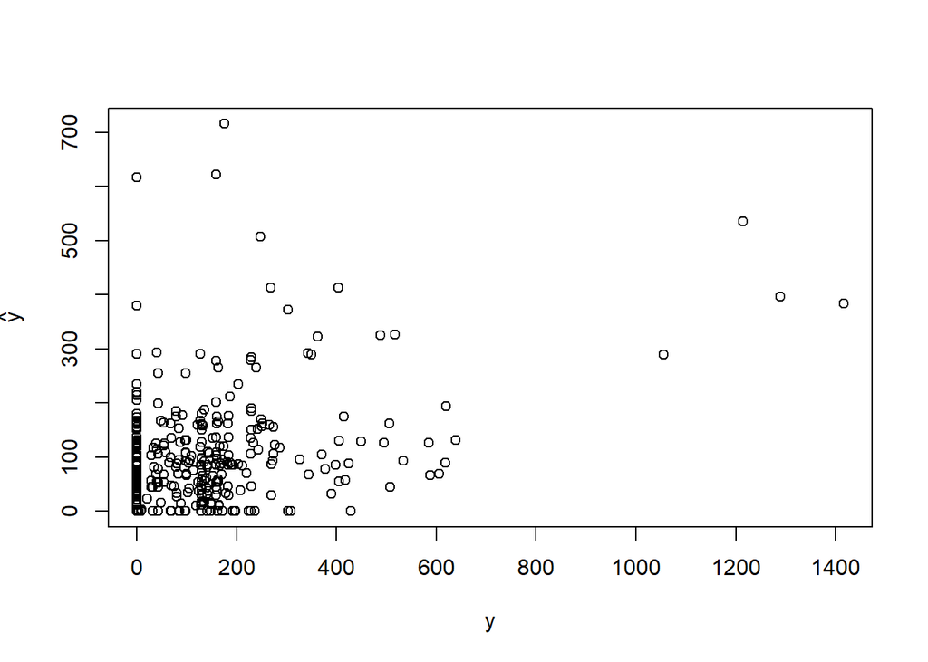

```r
plot(y_test$Spending, knn_reg$pred, xlab="y", ylab=expression(hat(y)))
```

```r
# Evaluate model using MAE and RMSE
cat("MAE for KNN is", MAE(y_test$Spending, knn_reg$pred), "\n")
```

```
## MAE for KNN is 87.23
```

```r
cat("RMSE for KNN is", RMSE(y_test$Spending, knn_reg$pred ))
```

```
## RMSE for KNN is 149.83
```

```r
# Add results into reg_results dataframe
reg_results[nrow(reg_results) + 1,] <-  list(Model = "KNN reg",
                                             MAE = MAE(y_test$Spending,knn_reg$pred ),
                                            RMSE = RMSE(y_test$Spending,knn_reg$pred))
```

## 1.3 Regression Tree

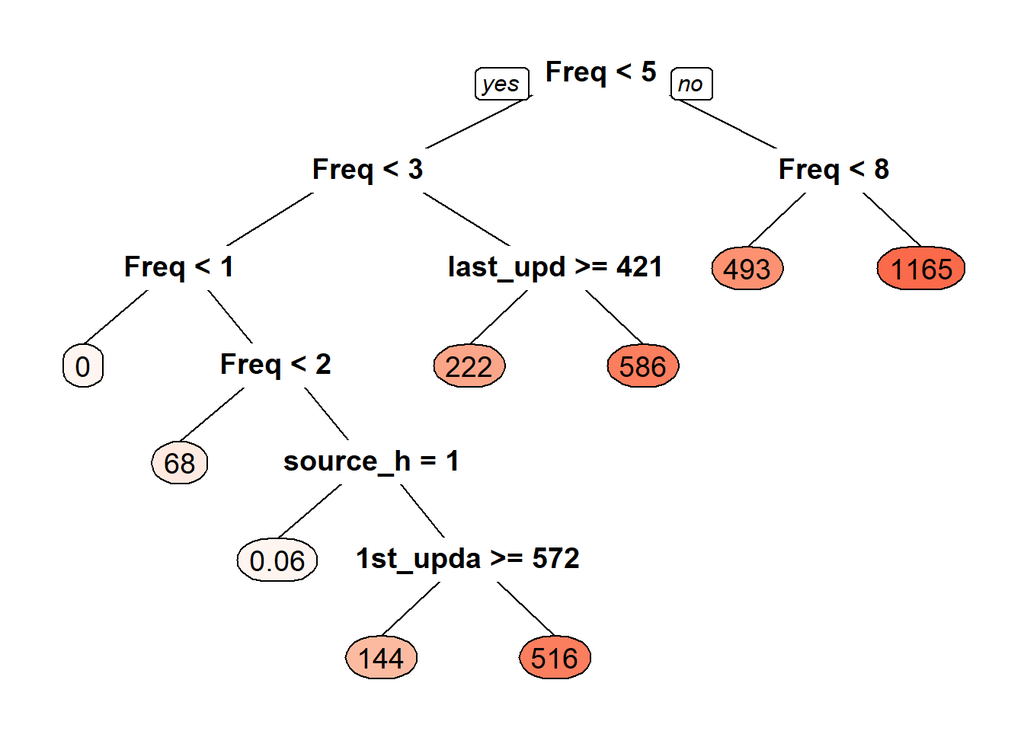

```r
# Cross validation
cross_validation <- trainControl(## 10-fold CV
                                method = "repeatedcv",
                                number = 10,
                                ## repeated three times
                                repeats = 3)
# Hyperparamter tuning
# maxdepth =  the maximum depth of the tree that will be created or
# the length of the longest path from the tree root to a leaf.

Param_Grid <-  expand.grid(maxdepth = 2:20)


reg_tree_fit <- train(x_train,
                       y_train$Spending,
                       method = "rpart2",
                       parms = list(split = "information"),
                        tuneGrid = Param_Grid,
                        trControl = cross_validation)




prp(reg_tree_fit$finalModel, box.palette = "Reds", tweak = 1.2)
```

```r
## prediction on test data
reg_tree_pred <- predict(reg_tree_fit, x_test)
```

```r
# Evaluate model using MAE and RMSE
cat("MAE for Regression Tree is", MAE(y_test$Spending,reg_tree_pred ), "\n")
```

```
## MAE for Regression Tree is 67.84
```

```r
cat("RMSE for Regression Tree is", RMSE(y_test$Spending,reg_tree_pred ))
```

```
## RMSE for Regression Tree is 112
```

```r
# Add results into reg_results dataframe
reg_results[nrow(reg_results) + 1,] <-  list(Model = "Reg Tree",
                                             MAE = MAE(y_test$Spending,reg_tree_pred ),
                                            RMSE =  RMSE(y_test$Spending,reg_tree_pred))
```

## 1.4 Linear regression

### 1.4.1 Linear regression with out regularization

```r
# preProc -  perform listed pre-processing to predictor data
linear_fit <- train(x_train,
               y_train$Spending,
               method = "lm",
               preProc = c("center", "scale"))
# prediction on test data
linear_pred <- predict(linear_fit, x_test)
```

```r
# Evaluate model using MAE and RMSE
cat("MAE for Linear regression is", MAE(y_test$Spending,linear_pred ), "\n")
```

```
## MAE for Linear regression is 71.37
```

```r
cat("RMSE for Linear regression is", RMSE(y_test$Spending,linear_pred ))
```

```
## RMSE for Linear regression is 103.57
```

```r
# Add results into reg_results dataframe
reg_results[nrow(reg_results) + 1,] <-  list(Model = "Linear reg",
                                             MAE = MAE(y_test$Spending,linear_pred ),
                                            RMSE =  RMSE(y_test$Spending,linear_pred ))
```

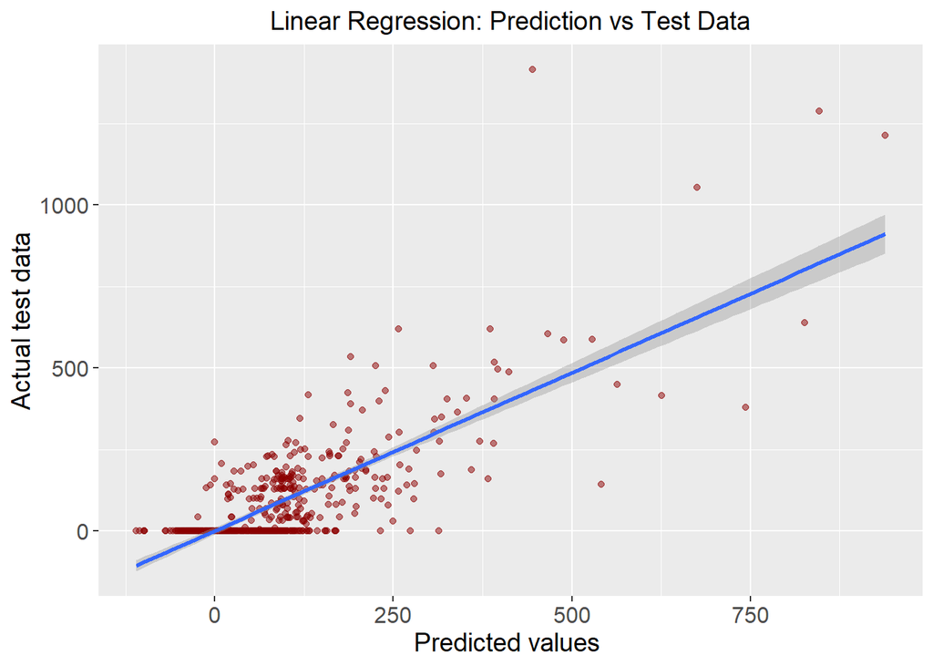

```r
# Plot linear model along with predicted and actual test data
my_data = as.data.frame(cbind(predicted = linear_pred,
                              observed = y_test$Spending))

ggplot(my_data,aes(predicted, observed)) +
  geom_point(color = "darkred", alpha = 0.5) +
  geom_smooth(method=lm)+
  ggtitle("Linear Regression: Prediction vs Test Data") +
  xlab("Predicted values ") +
  ylab("Actual test data") +
  theme(plot.title = element_text(color="black",size=14,hjust = 0.5),
        axis.text.y = element_text(size=12),
        axis.text.x = element_text(size=12,hjust=.5),
        axis.title.x = element_text(size=14),
        axis.title.y = element_text(size=14))
```

### 1.4.2 Ridge regression

```r
# select range of lamdas # this is very wide range
lambdas_to_try <- 10^seq(-3, 5, length.out = 100) # 1o^-3 smallest and 1065 is the largest -- 100 values to #try

# Setting alpha = 0 implements ridge regression
# when alpha =1 we are in lasso
# when alpha between 0 and 1, we are in Elastic Net(combination of lasso and ridge)
# alpha= .4; .4 ridge, and .6 lasso
# alpha= .5; .5 ridge penalty, and .5 lasso penalty
ridge_cv <- cv.glmnet(x_train %>% as.matrix(), y_train$Spending %>% as.matrix(),
                      alpha = 0, lambda = lambdas_to_try,
                      standardize = TRUE)
```

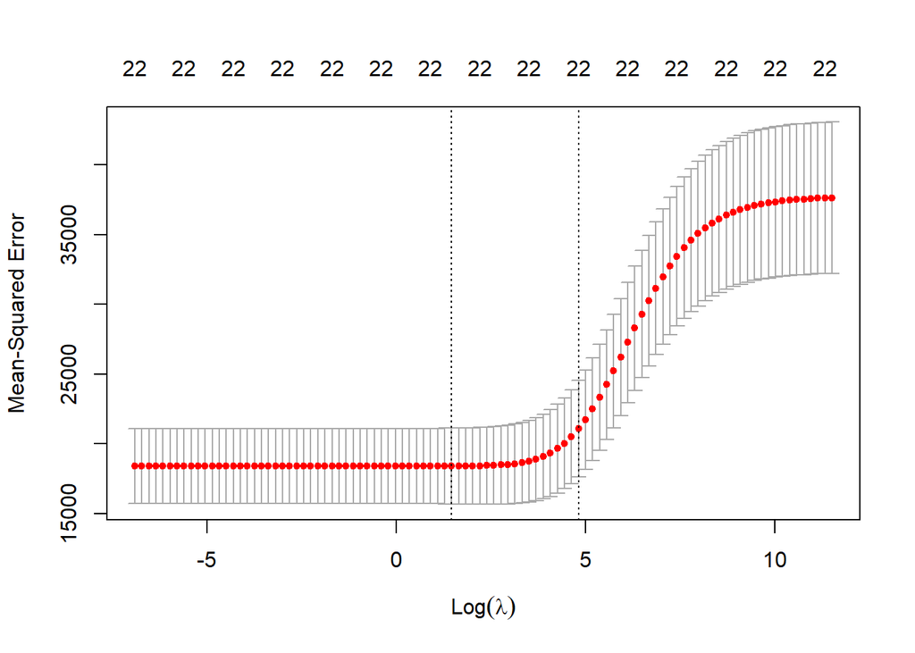

```r
# plot MSE vs Log(lambda)
plot(ridge_cv)
```

```r
# select the best cross-validated lambda
lambda_cv <- ridge_cv$lambda.min #best lambda

cat("Best lambda for Ridge Regression (alpha = 0)  is", lambda_cv)
```

```
## Best lambda for Ridge Regression (alpha = 0)  is 4.328761
```

```r
# Train the model using best lamda
model_ridge_cv <- glmnet(x_train %>% as.matrix(), y_train$Spending %>% as.matrix(),
                   alpha = 0, lambda = lambda_cv, standardize = TRUE)

# prediction on test data
ridge_predict <- predict(model_ridge_cv, x_test %>% as.matrix())
```

```r
# Evaluate model using MAE and RMSE
cat("MAE for Ridge regression is", MAE(y_test$Spending,ridge_predict ))
```

```
## MAE for Ridge regression is 71.07
```

```r
cat("RMSE for Ridge regression is", RMSE(y_test$Spending,ridge_predict ))
```

```
## RMSE for Ridge regression is 103.6
```

```r
# Add results into reg_results dataframe
reg_results[nrow(reg_results) + 1,] <-  list(Model = "Ridge reg",
                                             MAE = MAE(y_test$Spending,ridge_predict ),
                                            RMSE =  RMSE(y_test$Spending,ridge_predict ))
```